# Práctica 12. Análisis de expresión diferencial

Última actualización:

16 de mayo de 2026

## Datos

He instalado el paquete de bioconductor `DESeq2`. También he descargado los archivos de datos `salmon.merged.gene_counts.tsv` y `dme_elev_samples.tsv` de (Zhao 2015).

## Exploración de los datos

```r
muestras <- read.table('../../data/dme_elev_samples.tsv', header = TRUE)
genex <- read.table('../../data/salmon.merged.gene_counts.tsv',
                    header = TRUE)
```

**Ejercicio 1**

Recuerda dejar constancia en un bloque de código de cómo obtienes las respuestas.

1. Usa la función `paste()` para añadir una columna a `muestras` que contenga la población y la temperatura unidas por `_`.

```r
muestras$pop_temp <- paste(muestras$population,
                        muestras$temp,
                        sep = "_")
```

2. ¿Cuál es el número total de lecturas por muestra?

```r
counts <- genex[, !(colnames(genex) %in% c("gene_id", "gene_name"))]
total_lecturas_muestra<- colSums(counts)
total_lecturas_muestra
```

```
SRR1576457 SRR1576458 SRR1576459 SRR1576460 SRR1576461 SRR1576462 SRR1576463
  28252778   21565448   29471559   27692134   26953900   29368135   29706071
SRR1576464 SRR1576465 SRR1576514 SRR1576515 SRR1576516
  26757043   26596118   30950499   25563787   24401671
```

3. ¿Los recuentos tienen distribuciones parecidas entre muestras?

Contienen distribuciones parecidas a lo largo de todas las muestras como muestra la figura siguiente.

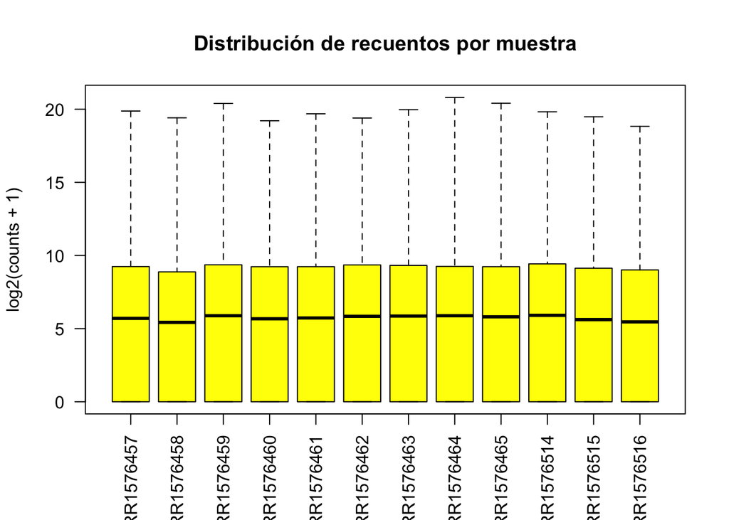

```r
boxplot(log2(counts + 1),
        las = 2,
        col = "yellow",
        main = "Distribución de recuentos por muestra",
        ylab = "log2(counts + 1)")
```

Se usa `log2(counts + 1)` para comprimir los valores muy altos y poder incluir los ceros sin errores, facilitando la comparación de las distribuciones entre muestras.

4. ¿Cuántos genes no se expresan en absoluto en ninguna de las muestras?

```r
genes_no_expresados <- sum(rowSums(counts, na.rm = TRUE) == 0)
genes_no_expresados
```

```
[1] 4722
```

## Crear el objeto de clase `DESeqDataSet`

Siguiendo el código proporcioando en el guión de prácticas, creo el objeto `DESeqDataSet`.

```r
suppressMessages(library('DESeq2'))
all(names(genex)[3:14] == muestras$sample)
```

```
[1] TRUE
```

```r
# Pasamos la columna "sample" a nombres de fila:
row.names(muestras) <- muestras$sample
# Eliminamos la columna "sample":
muestras$sample <- NULL
# Y convertimos "population" y "temp" en factores:
muestras$population <- factor(muestras$population,
                              levels = c('maine', 'panama'))
muestras$temp       <- factor(muestras$temp,
                              levels = c('low', 'high'))
muestras
```

```
           population temp    pop_temp
SRR1576457      maine  low   maine_low
SRR1576458      maine  low   maine_low
SRR1576459      maine  low   maine_low
SRR1576460      maine high  maine_high
SRR1576461      maine high  maine_high
SRR1576462      maine high  maine_high
SRR1576463     panama  low  panama_low
SRR1576464     panama  low  panama_low
SRR1576465     panama  low  panama_low
SRR1576514     panama high panama_high
SRR1576515     panama high panama_high
SRR1576516     panama high panama_high
```

```r
row.names(genex) <- genex$gene_name
genex$gene_name <- NULL
genex$gene_id   <- NULL
genex <- round(as.matrix(genex))
```

```r
dds1 <- DESeqDataSetFromMatrix(
   countData = genex,
   colData = muestras,
   design = ~ population + temp
)
dds1
```

```
class: DESeqDataSet
dim: 24254 12
metadata(1): version
assays(1): counts
rownames(24254): 7SLRNA:CR32864 a ... RR51477 Bari1{}RR51478
rowData names(0):
colnames(12): SRR1576457 SRR1576458 ... SRR1576515 SRR1576516
colData names(3): population temp pop_temp
```

Una vez hecho esto ya tenemos el objeto `DESeqDataSet` creado.

## Pre-filtrado

```r
keep <- rowSums(counts(dds1)) > 0
dds1 <- dds1[keep, ]
```

## Expresión diferencial

La función `DESeq()` produce un objeto también de clase `DESeqDataSet`, pero con resultados añadidos.

```r
dds1 <- DESeq(dds1)
res <- results(dds1)
res
```

```
log2 fold change (MLE): temp high vs low
Wald test p-value: temp high vs low
DataFrame with 19508 rows and 6 columns
                baseMean log2FoldChange     lfcSE       stat      pvalue
               <numeric>      <numeric> <numeric>  <numeric>   <numeric>
7SLRNA:CR32864   346.333      0.5918974 1.3301901   0.444972 0.656339979
a                555.596     -0.2730041 0.0718499  -3.799642 0.000144905
abd-A            531.996     -0.0286785 0.0789230  -0.363373 0.716326039
Abd-B            634.760     -0.1083918 0.0771252  -1.405401 0.159902101
Abl             1654.842     -0.1328055 0.0746587  -1.778834 0.075267032
...                  ...            ...       ...        ...         ...
RR51007          4.90906      3.8596869  2.972471  1.2984773 1.94123e-01
RR51048         16.60710     -0.8973069  0.341609 -2.6267095 8.62149e-03
RR51093         36.93279      0.0660523  1.685323  0.0391927 9.68737e-01
RR51475        159.62678     -2.6058194  1.875172 -1.3896429 1.64637e-01
RR51477         70.83394      1.6927984  0.192440  8.7965037 1.41145e-18
                      padj
                 <numeric>
7SLRNA:CR32864  0.81170166
a               0.00154616
abd-A           0.85146938
Abd-B           0.33850451
Abl             0.20047565
...                    ...
RR51007        3.82417e-01
RR51048        4.01797e-02
RR51093        9.84464e-01
RR51475        3.44823e-01
RR51477        2.06676e-16
```

**Ejercicio 3**

1. Mira la ayuda de results() y genera también la tabla de resultados para el contraste entre las dos regiones de procedencia de las moscas.

```r
res_pop <- results(dds1, name = "population_panama_vs_maine")
res_pop
```

```
log2 fold change (MLE): population panama vs maine
Wald test p-value: population panama vs maine
DataFrame with 19508 rows and 6 columns
                baseMean log2FoldChange     lfcSE      stat     pvalue
               <numeric>      <numeric> <numeric> <numeric>  <numeric>
7SLRNA:CR32864   346.333     -0.2116106 1.3301901 -0.159083  0.8736035
a                555.596     -0.1114458 0.0718345 -1.551424  0.1208001
abd-A            531.996      0.0460822 0.0789237  0.583882  0.5592996
Abd-B            634.760     -0.0424386 0.0771237 -0.550267  0.5821366
Abl             1654.842     -0.1477705 0.0746588 -1.979279  0.0477846
...                  ...            ...       ...       ...        ...
RR51007          4.90906       2.118240  2.970241  0.713154 0.47575037
RR51048         16.60710      -1.274560  0.344513 -3.699600 0.00021594
RR51093         36.93279      -0.886468  1.685327 -0.525992 0.59889395
RR51475        159.62678       0.121496  1.875169  0.064792 0.94833965
RR51477         70.83394      -0.187566  0.188821 -0.993353 0.32053776
                     padj
                <numeric>
7SLRNA:CR32864   0.966480
a                0.449968
abd-A            0.838012
Abd-B            0.850247
Abl              0.288750
...                   ...
RR51007        0.79163008
RR51048        0.00812472
RR51093        0.85673917
RR51475        0.98600913
RR51477        0.67813659
```

```r
res_temp <- results(dds1, name = "temp_high_vs_low")
res_temp
```

```
log2 fold change (MLE): temp high vs low
Wald test p-value: temp high vs low
DataFrame with 19508 rows and 6 columns
                baseMean log2FoldChange     lfcSE       stat      pvalue
               <numeric>      <numeric> <numeric>  <numeric>   <numeric>
7SLRNA:CR32864   346.333      0.5918974 1.3301901   0.444972 0.656339979
a                555.596     -0.2730041 0.0718499  -3.799642 0.000144905
abd-A            531.996     -0.0286785 0.0789230  -0.363373 0.716326039
Abd-B            634.760     -0.1083918 0.0771252  -1.405401 0.159902101
Abl             1654.842     -0.1328055 0.0746587  -1.778834 0.075267032
...                  ...            ...       ...        ...         ...
RR51007          4.90906      3.8596869  2.972471  1.2984773 1.94123e-01
RR51048         16.60710     -0.8973069  0.341609 -2.6267095 8.62149e-03
RR51093         36.93279      0.0660523  1.685323  0.0391927 9.68737e-01
RR51475        159.62678     -2.6058194  1.875172 -1.3896429 1.64637e-01
RR51477         70.83394      1.6927984  0.192440  8.7965037 1.41145e-18
                      padj
                 <numeric>
7SLRNA:CR32864  0.81170166
a               0.00154616
abd-A           0.85146938
Abd-B           0.33850451
Abl             0.20047565
...                    ...
RR51007        3.82417e-01
RR51048        4.01797e-02
RR51093        9.84464e-01
RR51475        3.44823e-01
RR51477        2.06676e-16
```

Si el log2FoldChange es positivo hay mayor expresión en Panama y si es negativo es en Maine.

2. Usa summary() sobre los resultados para ver el número de genes diferencialmente expresados entre cada par de condiciones.

```r
summary(res_pop)
```

```
out of 19508 with nonzero total read count
adjusted p-value < 0.1
LFC > 0 (up)       : 623, 3.2%
LFC < 0 (down)     : 634, 3.2%
outliers [1]       : 90, 0.46%
low counts [2]     : 3018, 15%
(mean count < 2)
[1] see 'cooksCutoff' argument of ?results
[2] see 'independentFiltering' argument of ?results
```

623 genes está up-regulated, es decir, tiene un log2FoldChange positivo, entonces se expresa más en Panama. 634 genes está down-regulated, es decir, tiene un log2FoldChange negativo, entonces se expresa más en Maine.

```r
summary(res_temp)
```

```
out of 19508 with nonzero total read count
adjusted p-value < 0.1
LFC > 0 (up)       : 2418, 12%
LFC < 0 (down)     : 2336, 12%
outliers [1]       : 90, 0.46%
low counts [2]     : 3018, 15%
(mean count < 2)
[1] see 'cooksCutoff' argument of ?results
[2] see 'independentFiltering' argument of ?results
```

2418 genes está up-regulated, es decir, tiene un log2FoldChange positivo, entonces se expresa más cuando la temperatura es alta. 2336 genes está down-regulated, es decir, tiene un log2FoldChange negativo, entonces se expresa más cuando la temperatura es baja.

3. ¿Cuál es la tasa de falsos positivos (FDR)?

El p-valor está ajustado a < 0.1, entonces el FDR es de un 10%. Aproximadamente, el 10% de genes que están significativamente expresados son falsos positivos.

## Gráficas

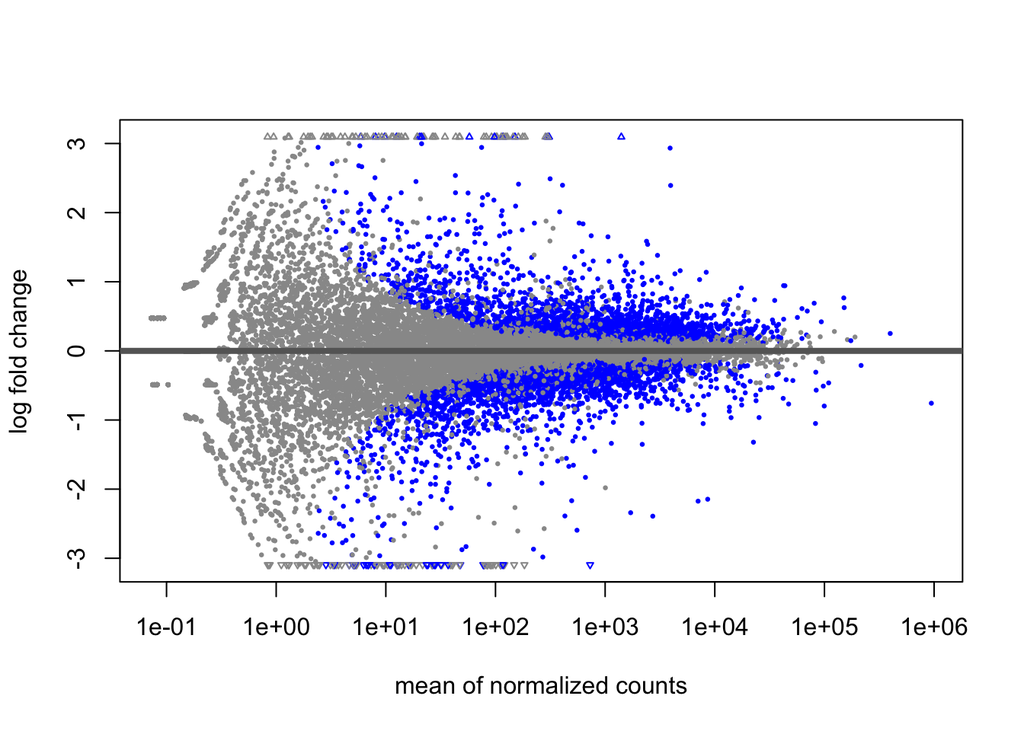

```r
plotMA(res)
```

```r
resShrink <- lfcShrink(dds1, coef = 'temp_high_vs_low',
                       type = 'normal')
```

```
using 'normal' for LFC shrinkage, the Normal prior from Love et al (2014).

Note that type='apeglm' and type='ashr' have shown to have less bias than type='normal'.
See ?lfcShrink for more details on shrinkage type, and the DESeq2 vignette.
Reference: https://doi.org/10.1093/bioinformatics/bty895
```

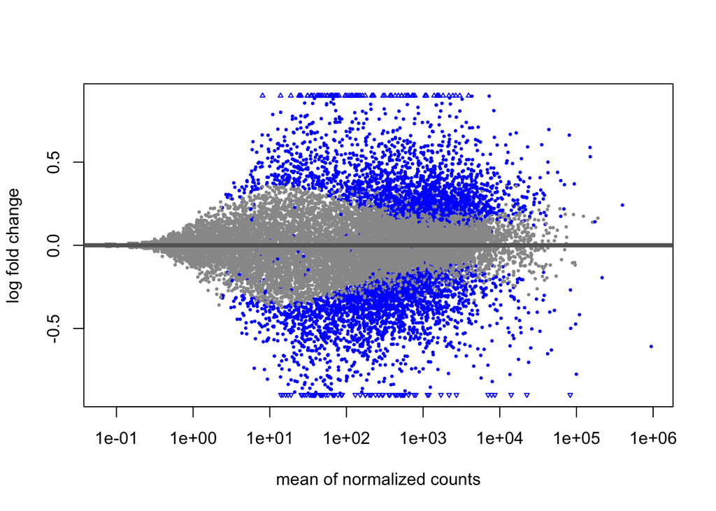

```r
plotMA(resShrink)
```

**Ejercicio 4**

¿Sabrías hacer una gráfica volcán?

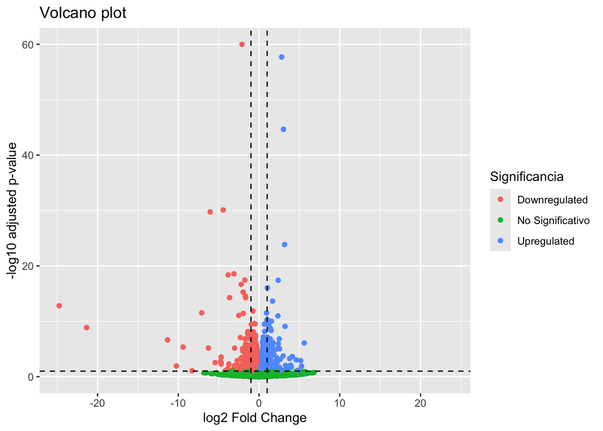

```r
#Crear una variable de significancia
res_pop$Significancia <- "No Significativo"
res_pop$Significancia[res_pop$padj < 0.1 & res_pop$log2FoldChange > 0] <- "Upregulated"
res_pop$Significancia[res_pop$padj < 0.1 & res_pop$log2FoldChange < 0] <- "Downregulated"

library(ggplot2)

df <- as.data.frame(res_pop)

df$Significancia <- "No Significativo"
df$Significancia[df$padj < 0.1 & df$log2FoldChange > 0] <- "Upregulated"
df$Significancia[df$padj < 0.1 & df$log2FoldChange < 0] <- "Downregulated"
ggplot(df, aes(x = log2FoldChange, y = -log10(padj))) +
  geom_point(aes(color = Significancia)) +
  geom_hline(yintercept = -log10(0.1), linetype = "dashed") +
  geom_vline(xintercept = c(-1, 1), linetype = "dashed") +
  labs(title = "Volcano plot",
       x = "log2 Fold Change",
       y = "-log10 adjusted p-value")
```

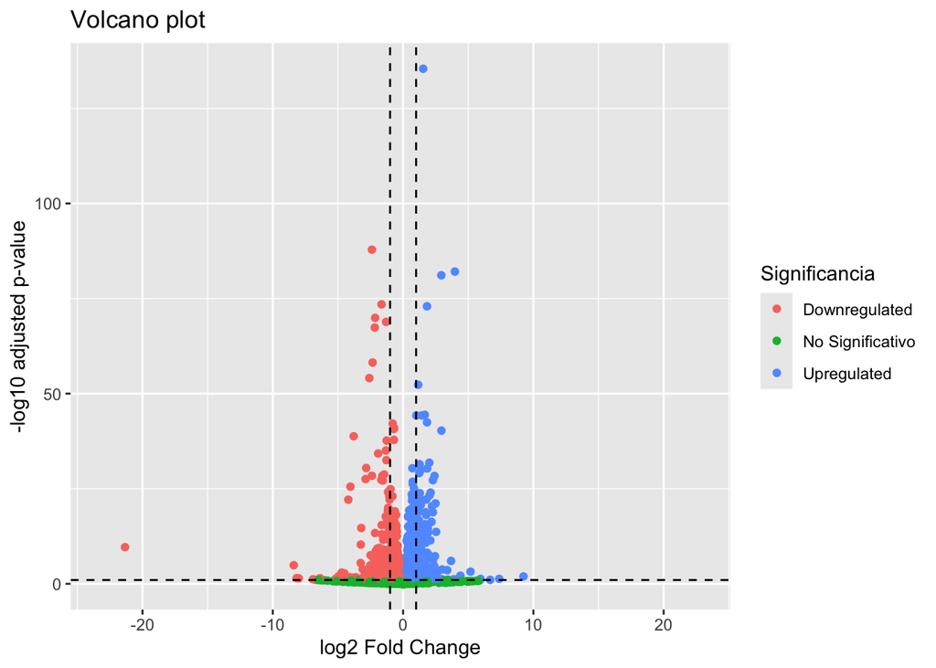

```r
#Crear una variable de significancia
res_temp$Significancia <- "No Significativo"
res_temp$Significancia[res_temp$padj < 0.1 & res_temp$log2FoldChange > 0] <- "Upregulated"
res_temp$Significancia[res_temp$padj < 0.1 & res_temp$log2FoldChange < 0] <- "Downregulated"

library(ggplot2)

df <- as.data.frame(res_temp)

df$Significancia <- "No Significativo"
df$Significancia[df$padj < 0.1 & df$log2FoldChange > 0] <- "Upregulated"
df$Significancia[df$padj < 0.1 & df$log2FoldChange < 0] <- "Downregulated"
ggplot(df, aes(x = log2FoldChange, y = -log10(padj))) +
  geom_point(aes(color = Significancia)) +
  geom_hline(yintercept = -log10(0.1), linetype = "dashed") +
  geom_vline(xintercept = c(-1, 1), linetype = "dashed") +
  labs(title = "Volcano plot",
       x = "log2 Fold Change",
       y = "-log10 adjusted p-value")
```

## Extraer datos transformados

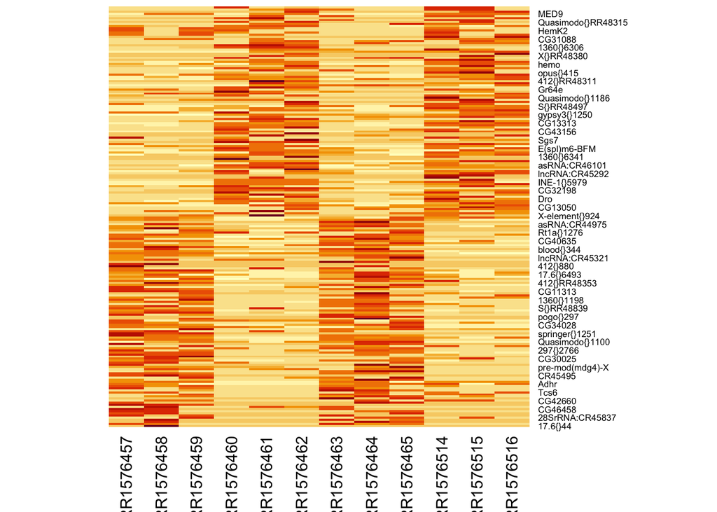

```r
dds2 <- vst(dds1)
NormCounts <- assay(dds2)

res <- res[! is.na(res$pvalue), ]
res <- res[order(res$log2FoldChange),]
heatmap(NormCounts[c(head(row.names(res), 100),
                     tail(row.names(res), 100)), ],
        Rowv = NA, Colv = NA)
```

**Ejercicio 5**

¿Podrías explicar qué hace el bloque de código anterior?

El código aplica primero una transformación VST (variance stabilizing transformation) al objeto `DESeqDataSet` para obtener valores de expresión normalizados comparables entre muestras, y extrae la matriz resultante con `assay()`. A continuación, se eliminan genes con valores de p-value ausentes y se ordenan los resultados según el log2FoldChange para identificar genes con mayor y menor cambio de expresión. Posteriormente, se seleccionan los 100 genes más sobreexpresados y los 100 más infraexpresados, que representan los extremos de la respuesta diferencial. Finalmente, se construye un heatmap sin clustering de filas ni columnas para visualizar los patrones de expresión de estos genes extremos a través de todas las muestras, permitiendo explorar de forma global las diferencias de expresión entre condiciones experimentales.

**Ejercicio 6**

En este enlace analizan exactamente los mismos datos con otro paquete de R: `limma`. Una de sus conclusiones es se sobreexpresan más genes en temperatura baja que en temperatura alta. ¿Confirma tu análisis esta conclusión?

En el análisis realizado, como expliqúe con anterioridad, 2418 genes está up-regulated, es decir, tiene un log2FoldChange positivo, entonces se expresa más cuando la temperatura es alta. 2336 genes está down-regulated, es decir, tiene un log2FoldChange negativo, entonces se expresa más cuando la temperatura es baja.

Por tanto se expresan más genes cuando la temperatura es alta que cuando la temperatura es baja y no se corresponde con el análisis de `limma`.

¿Cómo se comparan estos resultados con los tuyos?

```r
res_temp_df <- as.data.frame(res_temp)
res_temp_df$gene <- rownames(res_temp_df)
top10_temp <- res_temp_df[!is.na(res_temp_df$padj), ]
top10_temp <- top10_temp[order(top10_temp$padj), ]
head(top10_temp, 10)
```

```
                baseMean log2FoldChange      lfcSE      stat        pvalue
tim            2440.9985       1.540616 0.06108529  25.22074 2.372602e-140
Cpr92F         2718.9791      -2.391260 0.11722578 -20.39876  1.715118e-92
lncRNA:CR46017  116.9735       3.979874 0.20182996  19.71895  1.482864e-86
CG3739         3912.0444       2.933537 0.14974398  19.59035  1.868943e-85
Vajk3           513.4113      -1.654235 0.08864748 -18.66082  1.031376e-77
twi             628.6636       1.837146 0.09883693  18.58765  4.045070e-77
CG7214         8615.9336      -2.145943 0.11789951 -18.20145  5.025541e-74
mRpL9           507.5490      -1.304406 0.07223024 -18.05900  6.702868e-73
Acp1           7042.1924      -2.173942 0.12170472 -17.86243  2.313362e-71
CG40472        1708.3019      -2.340906 0.14074549 -16.63219  4.074038e-62
                        padj Significancia           gene
tim            3.891067e-136   Upregulated            tim
Cpr92F          1.406397e-88 Downregulated         Cpr92F
lncRNA:CR46017  8.106326e-83   Upregulated lncRNA:CR46017
CG3739          7.662665e-82   Upregulated         CG3739
Vajk3           3.382912e-74 Downregulated          Vajk3
twi             1.105653e-73   Upregulated            twi
CG7214          1.177413e-70 Downregulated         CG7214
mRpL9           1.374088e-69 Downregulated          mRpL9
Acp1            4.215459e-68 Downregulated           Acp1
CG40472         6.681422e-59 Downregulated        CG40472
```

## Bibliografía

Zhao, Janneke AND Svetec, Li AND Wit. 2015. «Parallel Gene Expression Differences between Low and High Latitude Populations of Drosophila melanogaster and D. simulans». *PLOS Genetics* 11 (5): 1-25. https://doi.org/10.1371/journal.pgen.1005184.